fossil

# Overestimation in meta-analysis, dug back up.

The authors' simulation code was never released. We rebuilt it from the paper and its appendices as the Python package oisim and reran all 36 scenarios, 20,000 meta-analyses of 100 trials each. Of 91 results, 0 are exact, 13 agree, 20 partly agree, 38 are inconclusive, 16 differ and 4 were not attempted. The main claim holds on our run.

See every resultSee the tables

## Install oisim

Python package

```
pip install "git+https://github.com/jeonglab-bcm/fossil#subdirectory=PMC3196500/package"
```

Python 3.10 or later; the only dependency is NumPy.

[README](https://github.com/jeonglab-bcm/fossil/blob/main/PMC3196500/package/README.md) [Tutorial](https://github.com/jeonglab-bcm/fossil/blob/main/PMC3196500/package/tutorial/TUTORIAL.md)

## Fig. 2

Fig. 2. Cochrane trial sizes, control risk 5% to 15%, tau2 0.15, no true effect: the share of pooled RRR above 30% (dash-dot) and 20% (dotted) against cumulative patients (upper) and events (lower).

Partly agrees

Published

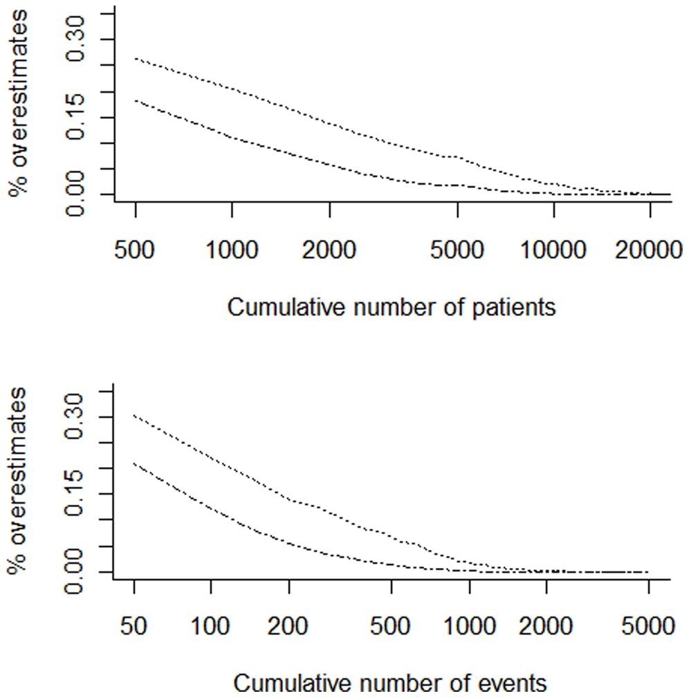

Our run

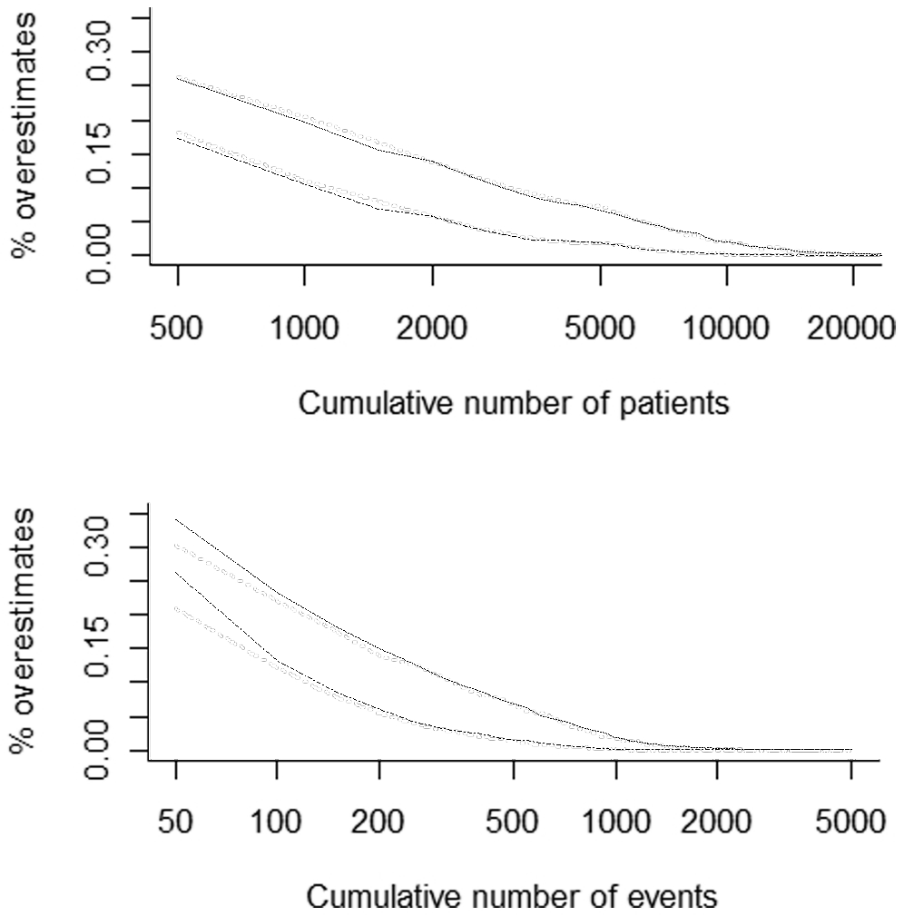

**upper panel**

**lower panel**

Our curves are drawn on the published pixel grid from the tick marks. A panel agrees when it beats every control and comes within 90% of how close our two runs with other seeds are to each other.

## Fig. S1

Fig. S1. Cochrane trial sizes, no true effect, against cumulative patients; control risk 1% to 5% (top) and 5% to 15% (bottom); tau2 0.05, 0.15, 0.25 from left to right.

Inconclusive

Published

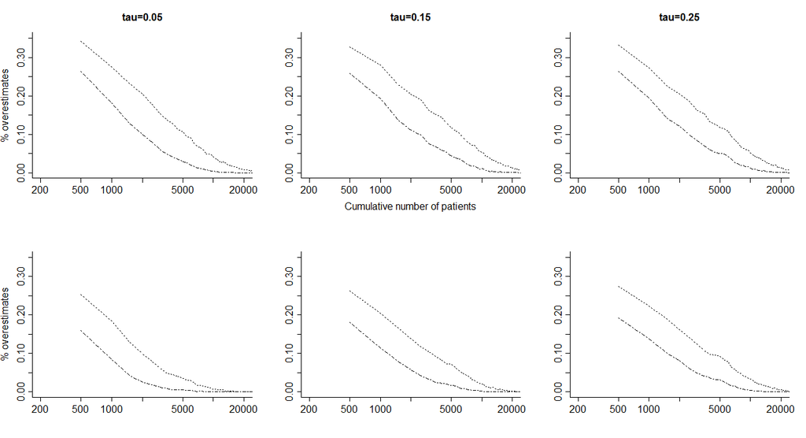

Our run

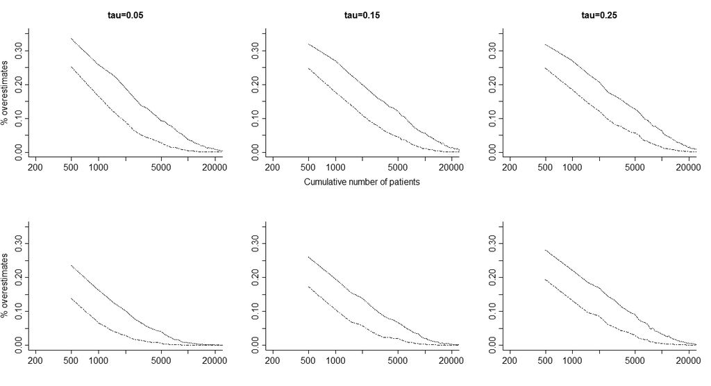

**top left**

42.2% within 2 px (pass 84.4%, best control 76.9%, our two runs 93.7%), Inconclusive

**top middle**

65.1% within 2 px (pass 85.6%, best control 80.1%, our two runs 95.1%), Inconclusive

**top right**

64.2% within 2 px (pass 88.0%, best control 54.9%, our two runs 97.8%), Partly agrees

**bottom left**

70.2% within 2 px (pass 89.7%, best control 68.5%, our two runs 99.6%), Partly agrees

**bottom middle**

**bottom right**

85.8% within 2 px (pass 82.9%, best control 62.4%, our two runs 92.1%), Agrees

Our curves are drawn on the published pixel grid from the tick marks. A panel agrees when it beats every control and comes within 90% of how close our two runs with other seeds are to each other.

## Fig. S2

Fig. S2. Cochrane trial sizes, no true effect, against cumulative events; control risk 1% to 5% (top) and 5% to 15% (bottom); tau2 0.05, 0.15, 0.25 from left to right.

Inconclusive

Published

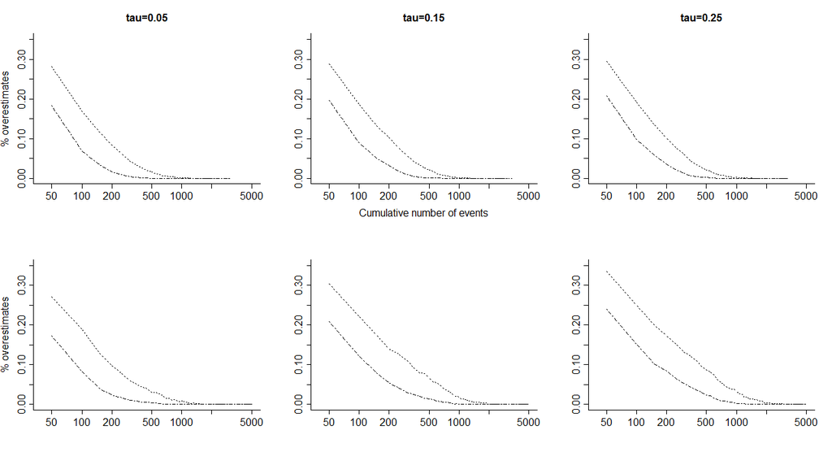

Our run

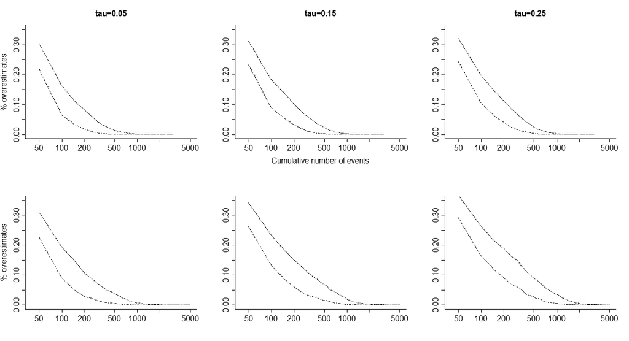

**top left**

77.7% within 2 px (pass 90.0%, best control 73.7%, our two runs 100.0%), Partly agrees

**top middle**

80.1% within 2 px (pass 90.0%, best control 83.2%, our two runs 100.0%), Inconclusive

**top right**

53.8% within 2 px (pass 90.0%, best control 83.2%, our two runs 100.0%), Inconclusive

**bottom left**

52.2% within 2 px (pass 88.0%, best control 76.5%, our two runs 97.8%), Inconclusive

**bottom middle**

59.9% within 2 px (pass 89.6%, best control 80.6%, our two runs 99.5%), Inconclusive

**bottom right**

53.1% within 2 px (pass 81.3%, best control 77.0%, our two runs 90.3%), Inconclusive

Our curves are drawn on the published pixel grid from the tick marks. A panel agrees when it beats every control and comes within 90% of how close our two runs with other seeds are to each other.

## Fig. S3

Fig. S3. Cochrane trial sizes, true RRR 10%, against cumulative patients; control risk 1% to 5% (top) and 5% to 15% (bottom); tau2 0.05, 0.15, 0.25 from left to right.

Inconclusive

Published

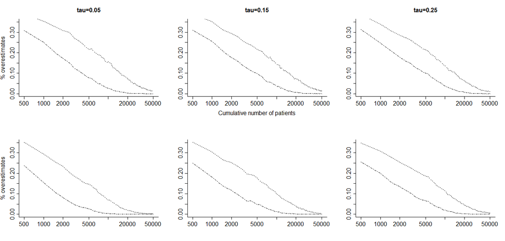

Our run

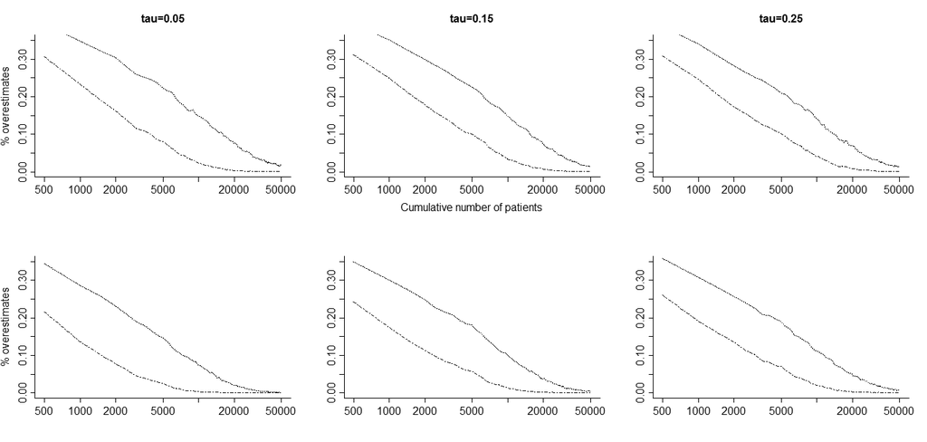

**top left**

64.5% within 2 px (pass 84.1%, best control 70.4%, our two runs 93.5%), Inconclusive

**top middle**

85.8% within 2 px (pass 65.5%, best control 58.7%, our two runs 72.8%), Agrees

**top right**

88.8% within 2 px (pass 86.8%, best control 50.9%, our two runs 96.4%), Agrees

**bottom left**

75.6% within 2 px (pass 76.7%, best control 62.1%, our two runs 85.2%), Partly agrees

**bottom middle**

81.9% within 2 px (pass 85.0%, best control 66.2%, our two runs 94.4%), Partly agrees

**bottom right**

91.3% within 2 px (pass 82.9%, best control 55.0%, our two runs 92.1%), Agrees

Our curves are drawn on the published pixel grid from the tick marks. A panel agrees when it beats every control and comes within 90% of how close our two runs with other seeds are to each other.

## Fig. S4

Fig. S4. Cochrane trial sizes, true RRR 10%, against cumulative events; control risk 1% to 5% (top) and 5% to 15% (bottom); tau2 0.05, 0.15, 0.25 from left to right.

Inconclusive

Published

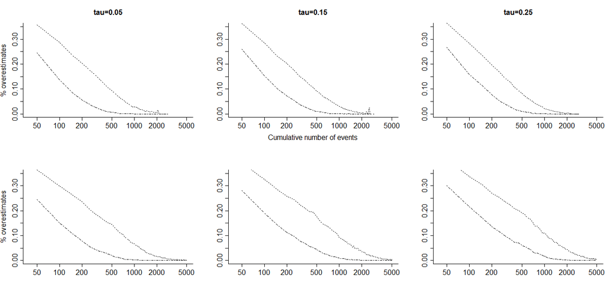

Our run

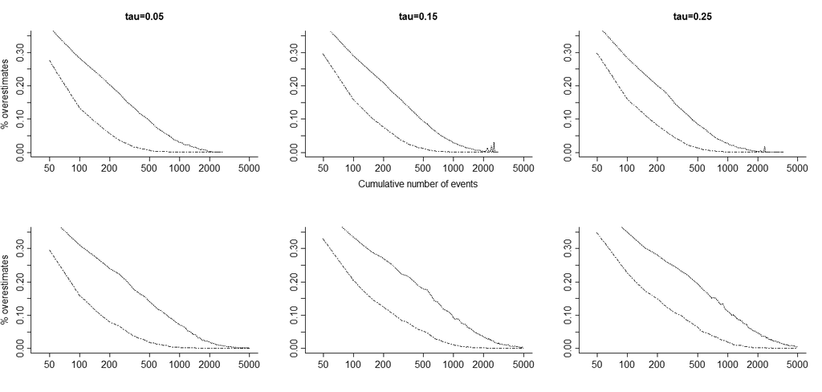

**top left**

85.7% within 2 px (pass 89.8%, best control 69.1%, our two runs 99.8%), Partly agrees

**top middle**

**top right**

78.2% within 2 px (pass 88.0%, best control 78.6%, our two runs 97.8%), Inconclusive

**bottom left**

65.7% within 2 px (pass 84.9%, best control 82.9%, our two runs 94.3%), Inconclusive

**bottom middle**

55.5% within 2 px (pass 87.2%, best control 74.3%, our two runs 96.9%), Inconclusive

**bottom right**

Our curves are drawn on the published pixel grid from the tick marks. A panel agrees when it beats every control and comes within 90% of how close our two runs with other seeds are to each other.

## Fig. S5

Fig. S5. 'common' trial sizes, no true effect, against cumulative patients; control risk 1% to 5% (top) and 5% to 15% (bottom); tau2 0.05, 0.15, 0.25 from left to right.

Differs

Published

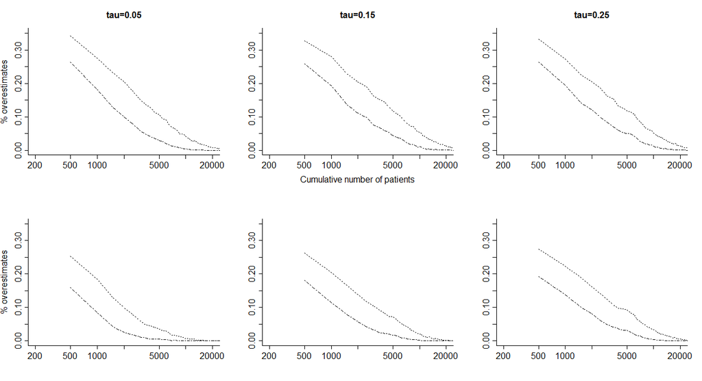

Our run

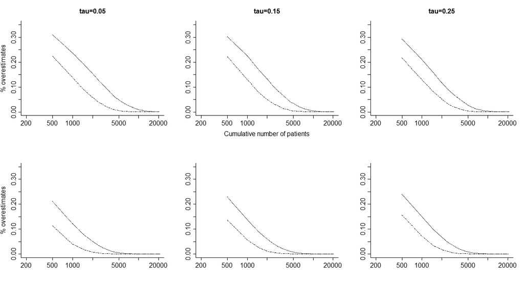

**top left**

11.3% within 2 px (pass 89.5%, best control 23.8%, our two runs 99.4%), Differs

**top middle**

18.3% within 2 px (pass 90.0%, best control 27.5%, our two runs 100.0%), Differs

**top right**

12.3% within 2 px (pass 85.5%, best control 20.1%, our two runs 95.1%), Differs

**bottom left**

28.1% within 2 px (pass 90.0%, best control 38.1%, our two runs 100.0%), Differs

**bottom middle**

27.6% within 2 px (pass 89.8%, best control 33.9%, our two runs 99.8%), Differs

**bottom right**

17.9% within 2 px (pass 89.1%, best control 31.4%, our two runs 99.0%), Differs

The paper's Fig. S5 file is a byte copy of Fig. S1: it shows the Cochrane-size scenario, not the 'common' one its caption names. Our 'common' curves are drawn here.

## Fig. S6

Fig. S6. 'common' trial sizes, no true effect, against cumulative events; control risk 1% to 5% (top) and 5% to 15% (bottom); tau2 0.05, 0.15, 0.25 from left to right.

Differs

Published

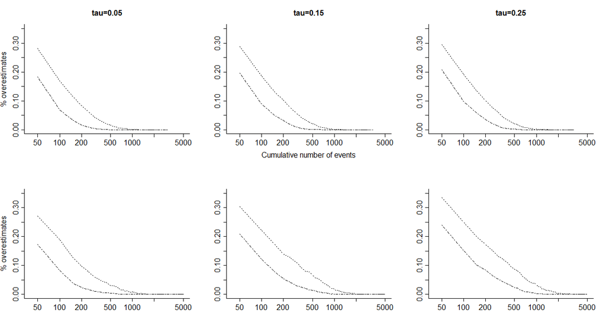

Our run

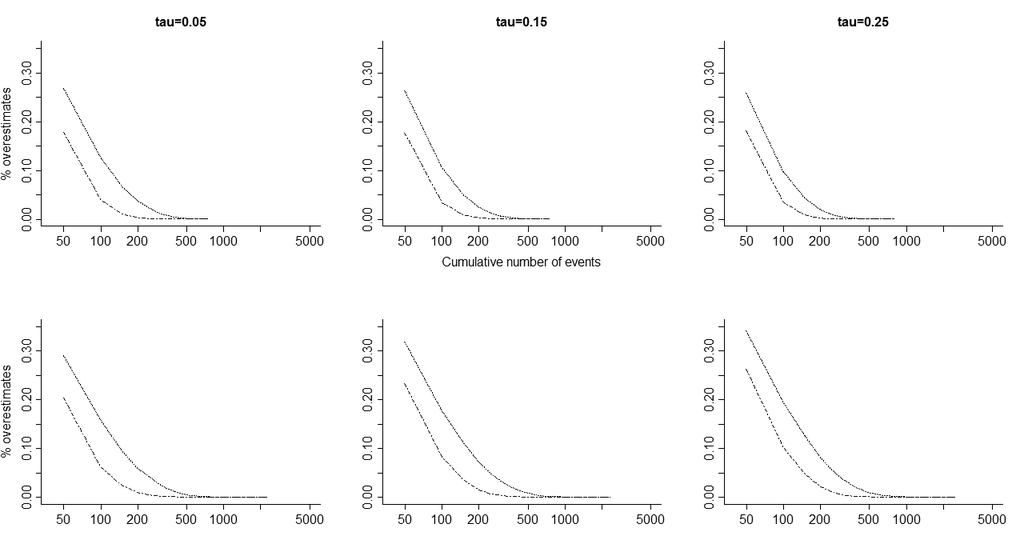

**top left**

16.7% within 2 px (pass 89.4%, best control 50.8%, our two runs 99.3%), Differs

**top middle**

21.5% within 2 px (pass 89.8%, best control 39.9%, our two runs 99.8%), Differs

**top right**

17.4% within 2 px (pass 89.6%, best control 39.5%, our two runs 99.5%), Differs

**bottom left**

33.8% within 2 px (pass 90.0%, best control 42.7%, our two runs 100.0%), Differs

**bottom middle**

32.6% within 2 px (pass 89.8%, best control 33.3%, our two runs 99.8%), Inconclusive

**bottom right**

22.2% within 2 px (pass 89.4%, best control 23.2%, our two runs 99.3%), Inconclusive

The paper's Fig. S6 file is a byte copy of Fig. S2: it shows the Cochrane-size scenario, not the 'common' one its caption names. Our 'common' curves are drawn here.

## Fig. S7

Fig. S7. 'common' trial sizes, true RRR 10%, against cumulative patients; control risk 1% to 5% (top) and 5% to 15% (bottom); tau2 0.05, 0.15, 0.25 from left to right.

Differs

Published

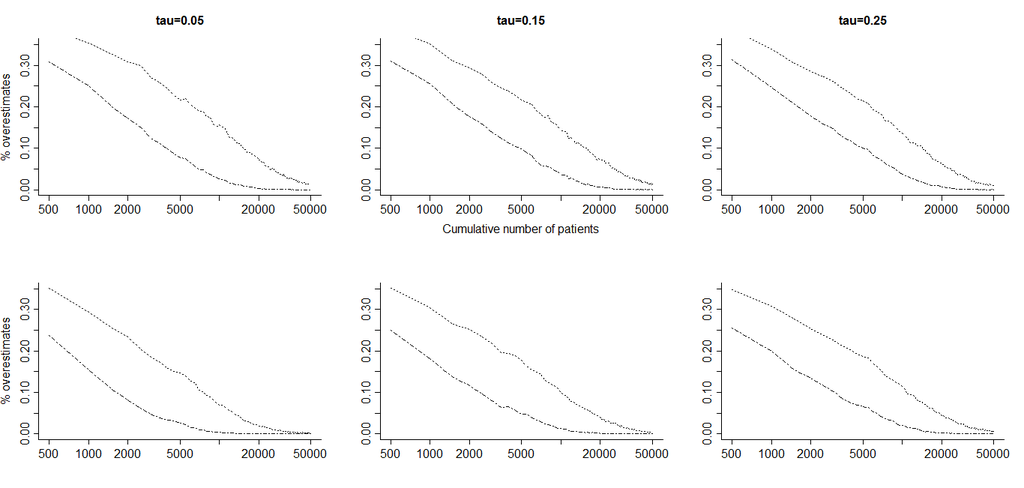

Our run

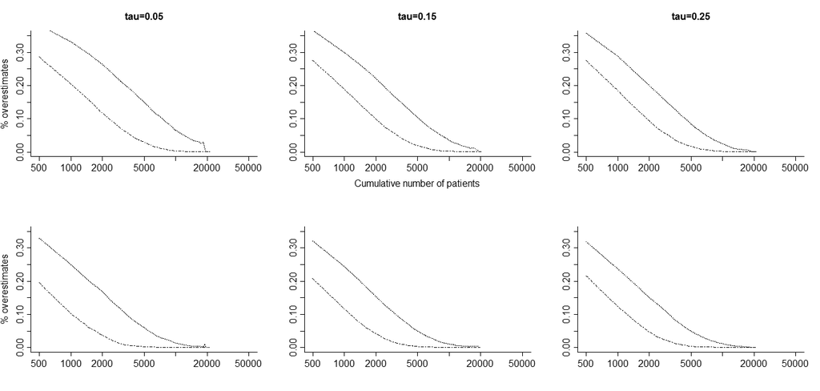

**top left**

2.4% within 2 px (pass 64.4%, best control 17.9%, our two runs 71.6%), Differs

**top middle**

16.8% within 2 px (pass 84.7%, best control 17.7%, our two runs 94.1%), Inconclusive

**top right**

5.7% within 2 px (pass 88.9%, best control 9.1%, our two runs 98.8%), Differs

**bottom left**

10.4% within 2 px (pass 87.6%, best control 31.4%, our two runs 97.4%), Differs

**bottom middle**

19.0% within 2 px (pass 87.4%, best control 20.7%, our two runs 97.1%), Differs

**bottom right**

10.1% within 2 px (pass 89.5%, best control 16.8%, our two runs 99.5%), Differs

The paper's Fig. S7 file is a byte copy of Fig. S3: it shows the Cochrane-size scenario, not the 'common' one its caption names. Our 'common' curves are drawn here.

## Fig. S8

Fig. S8. 'common' trial sizes, true RRR 10%, against cumulative events; control risk 1% to 5% (top) and 5% to 15% (bottom); tau2 0.05, 0.15, 0.25 from left to right.

Inconclusive

Published

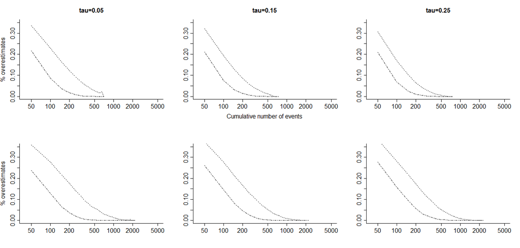

Our run

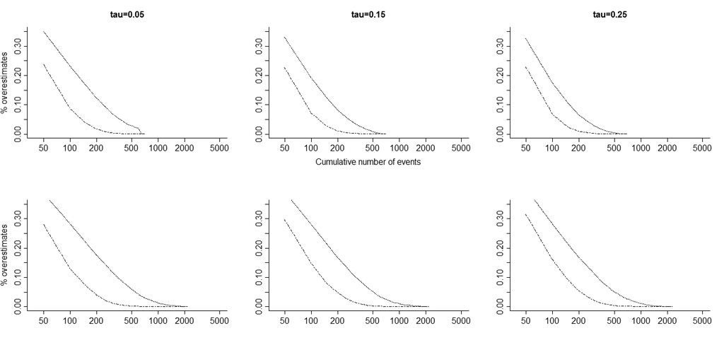

**top left**

**top middle**

94.0% within 2 px (pass 88.6%, best control 72.3%, our two runs 98.5%), Agrees

**top right**

**bottom left**

79.5% within 2 px (pass 89.7%, best control 79.5%, our two runs 99.7%), Partly agrees

**bottom middle**

84.4% within 2 px (pass 89.8%, best control 83.2%, our two runs 99.8%), Partly agrees

**bottom right**

81.6% within 2 px (pass 90.0%, best control 70.1%, our two runs 100.0%), Partly agrees

Our curves are drawn on the published pixel grid from the tick marks. A panel agrees when it beats every control and comes within 90% of how close our two runs with other seeds are to each other.

## Fig. S9

Fig. S9. 'common' trial sizes, no true effect, against cumulative patients; control risk 15% to 40% (top) and 40% to 80% (bottom); tau2 0.05, 0.15, 0.25 from left to right.

Inconclusive

Published

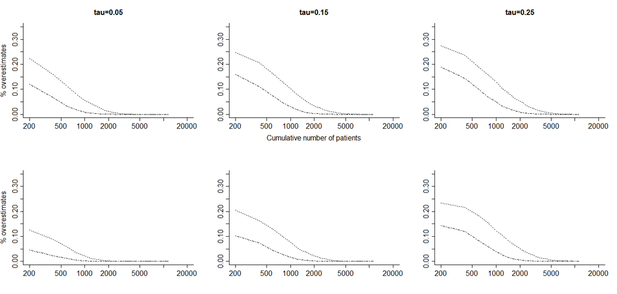

Our run

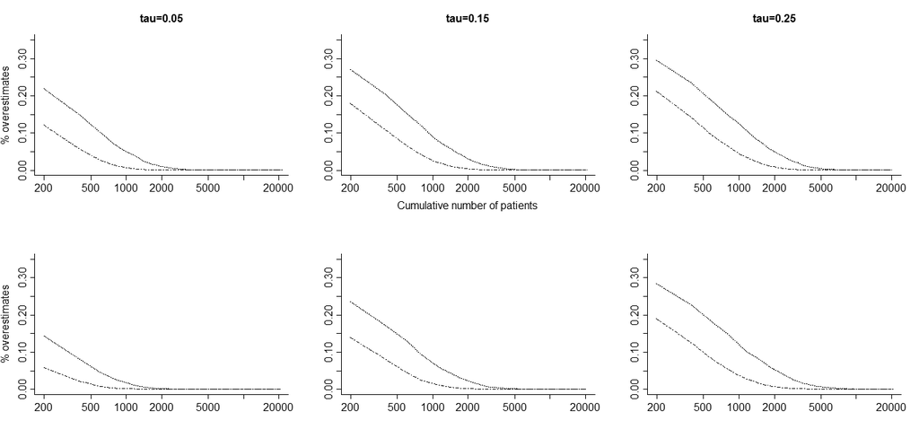

**top left**

63.4% within 2 px (pass 87.9%, best control 84.2%, our two runs 97.7%), Inconclusive

**top middle**

65.8% within 2 px (pass 90.0%, best control 73.0%, our two runs 100.0%), Inconclusive

**top right**

75.8% within 2 px (pass 89.7%, best control 74.8%, our two runs 99.7%), Partly agrees

**bottom left**

71.2% within 2 px (pass 89.8%, best control 73.2%, our two runs 99.8%), Inconclusive

**bottom middle**

71.4% within 2 px (pass 90.0%, best control 71.9%, our two runs 100.0%), Inconclusive

**bottom right**

74.8% within 2 px (pass 89.9%, best control 66.6%, our two runs 99.8%), Partly agrees

Our curves are drawn on the published pixel grid from the tick marks. A panel agrees when it beats every control and comes within 90% of how close our two runs with other seeds are to each other.

## Fig. S10

Fig. S10. 'common' trial sizes, no true effect, against cumulative events; control risk 15% to 40% (top) and 40% to 80% (bottom); tau2 0.05, 0.15, 0.25 from left to right.

Inconclusive

Published

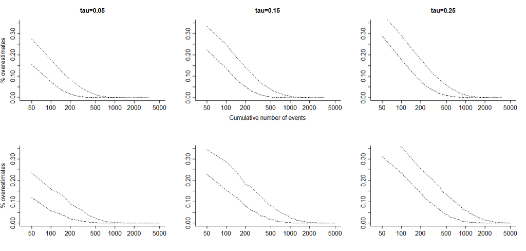

Our run

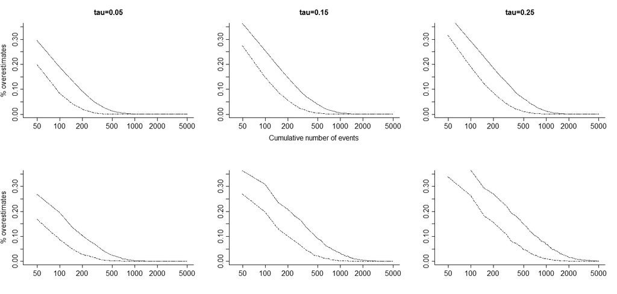

**top left**

57.6% within 2 px (pass 89.2%, best control 81.5%, our two runs 99.1%), Inconclusive

**top middle**

66.8% within 2 px (pass 90.0%, best control 83.0%, our two runs 100.0%), Inconclusive

**top right**

68.4% within 2 px (pass 89.3%, best control 83.7%, our two runs 99.2%), Inconclusive

**bottom left**

58.5% within 2 px (pass 87.8%, best control 68.8%, our two runs 97.6%), Inconclusive

**bottom middle**

47.2% within 2 px (pass 89.7%, best control 64.3%, our two runs 99.7%), Inconclusive

**bottom right**

51.1% within 2 px (pass 85.4%, best control 66.9%, our two runs 94.9%), Inconclusive

Our curves are drawn on the published pixel grid from the tick marks. A panel agrees when it beats every control and comes within 90% of how close our two runs with other seeds are to each other.

## Fig. S11

Fig. S11. 'common' trial sizes, true RRR 10%, against cumulative patients; control risk 15% to 40% (top) and 40% to 80% (bottom); tau2 0.05, 0.15, 0.25 from left to right.

Differs

Published

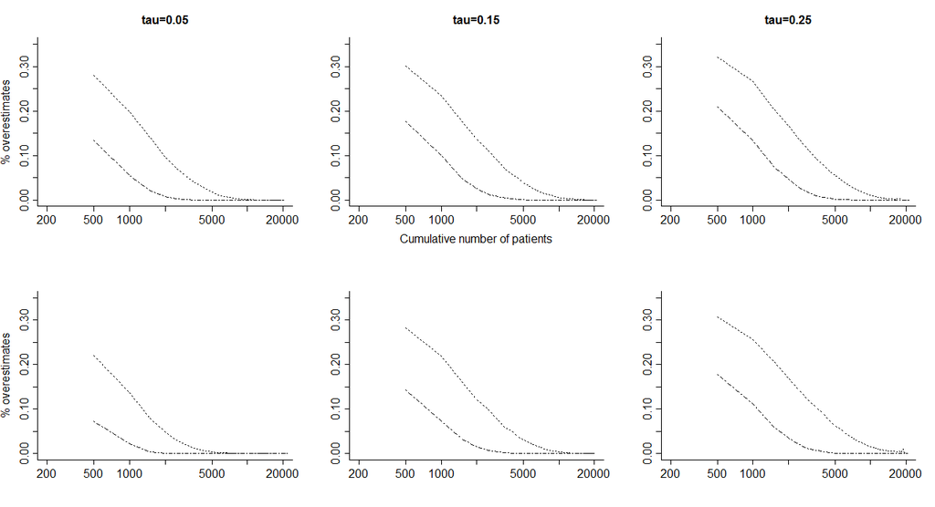

Our run

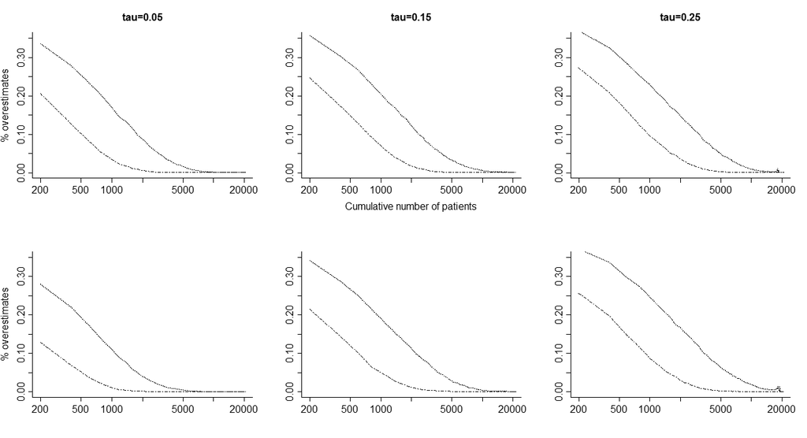

**top left**

38.9% within 2 px (pass 90.0%, best control 74.5%, our two runs 100.0%), Inconclusive

**top middle**

35.7% within 2 px (pass 89.9%, best control 71.8%, our two runs 99.8%), Inconclusive

**top right**

38.1% within 2 px (pass 89.3%, best control 65.4%, our two runs 99.2%), Inconclusive

**bottom left**

46.8% within 2 px (pass 85.5%, best control 78.2%, our two runs 95.0%), Inconclusive

**bottom middle**

45.8% within 2 px (pass 83.5%, best control 75.5%, our two runs 92.8%), Differs

**bottom right**

58.0% within 2 px (pass 76.1%, best control 61.9%, our two runs 84.6%), Inconclusive

Our curves are drawn on the published pixel grid from the tick marks. A panel agrees when it beats every control and comes within 90% of how close our two runs with other seeds are to each other.

## Fig. S12

Fig. S12. 'common' trial sizes, true RRR 10%, against cumulative events; control risk 15% to 40% (top) and 40% to 80% (bottom); tau2 0.05, 0.15, 0.25 from left to right.

Inconclusive

Published

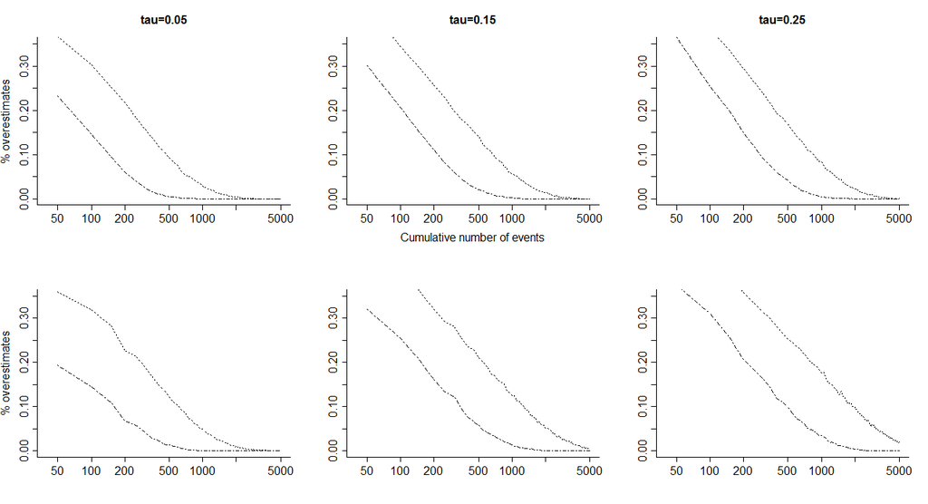

Our run

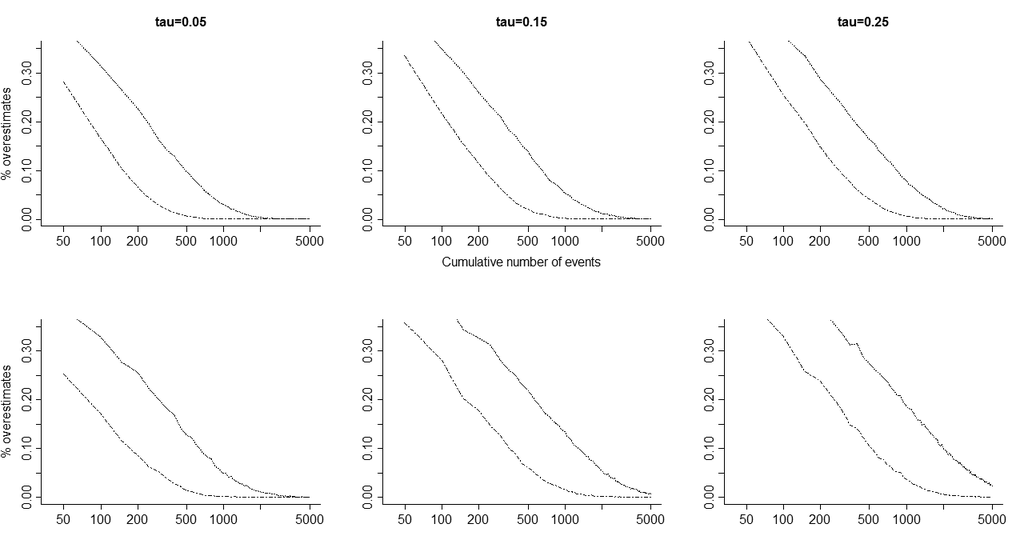

**top left**

63.3% within 2 px (pass 90.0%, best control 85.3%, our two runs 100.0%), Inconclusive

**top middle**

79.4% within 2 px (pass 88.3%, best control 69.7%, our two runs 98.1%), Partly agrees

**top right**

99.2% within 2 px (pass 89.7%, best control 66.3%, our two runs 99.7%), Agrees

**bottom left**

57.4% within 2 px (pass 81.8%, best control 72.9%, our two runs 90.9%), Inconclusive

**bottom middle**

67.0% within 2 px (pass 77.8%, best control 73.8%, our two runs 86.5%), Inconclusive

**bottom right**

37.1% within 2 px (pass 85.5%, best control 72.1%, our two runs 95.0%), Inconclusive

Our curves are drawn on the published pixel grid from the tick marks. A panel agrees when it beats every control and comes within 90% of how close our two runs with other seeds are to each other.

## The tables

Tables 1, S3 and S4 are read off our curves: the first point at which the share of overestimates drops below 10%, 5% or 1%. Table 2 is the OIS formula. Each cell shows the paper's value above ours.

## Table 1 (Cochrane trial sizes, PC 1-5% and 5-15%: patients and events required)

Paper above, ours below; shaded where ours is not the printed value. 81 of 144 cells as printed.

Partly agrees

| Scenario | patients 10% | patients 5% | patients 1% | events 10% | events 5% | events 1% |
| --- | --- | --- | --- | --- | --- | --- |
| RRR 0%, RRR>30%, PC 1-5%, tau2 0.05 | 2000 2500 | 3500 3500 | 8000 8500 | 100 100 | 150 150 | 300 250 |
| RRR 0%, RRR>30%, PC 1-5%, tau2 0.15 | 2500 2500 | 4500 5000 | 10500 10000 | 100 100 | 150 200 | 350 350 |
| RRR 0%, RRR>30%, PC 1-5%, tau2 0.25 | 3000 3000 | 5500 6000 | 11500 12000 | 150 150 | 200 200 | 350 350 |
| RRR 0%, RRR>30%, PC 5-15%, tau2 0.05 | 1000 1000 | 1500 2000 | 3500 4000 | 100 100 | 150 150 | 350 350 |
| RRR 0%, RRR>30%, PC 5-15%, tau2 0.15 | 1500 1500 | 2500 2500 | 6500 6500 | 150 150 | 250 250 | 600 650 |
| RRR 0%, RRR>30%, PC 5-15%, tau2 0.25 | 1500 2000 | 3500 3500 | 8000 8000 | 200 200 | 350 350 | 750 750 |
| RRR 0%, RRR>20%, PC 1-5%, tau2 0.05 | 5500 5500 | 9000 9500 | 19500 20000 | 200 200 | 300 300 | 600 600 |
| RRR 0%, RRR>20%, PC 1-5%, tau2 0.15 | 6500 6500 | 10500 11000 | 21500 21500 | 250 250 | 350 350 | 650 700 |
| RRR 0%, RRR>20%, PC 1-5%, tau2 0.25 | 6500 7000 | 11500 11500 | 23000 23500 | 250 250 | 350 400 | 700 700 |
| RRR 0%, RRR>20%, PC 5-15%, tau2 0.05 | 2500 2500 | 4000 4500 | 9000 9000 | 200 250 | 400 400 | 850 850 |
| RRR 0%, RRR>20%, PC 5-15%, tau2 0.15 | 3000 3500 | 6500 7000 | 13000 13500 | 350 350 | 600 650 | 1250 1250 |
| RRR 0%, RRR>20%, PC 5-15%, tau2 0.25 | 4500 5000 | 8000 8000 | 16500 16500 | 450 450 | 750 800 | 1650 1650 |
| RRR 10%, RRR>30%, PC 1-5%, tau2 0.05 | 4000 4500 | 7000 7000 | 14500 15000 | 150 150 | 250 250 | 450 450 |
| RRR 10%, RRR>30%, PC 1-5%, tau2 0.15 | 5500 5500 | 9000 9000 | 18000 18500 | 200 200 | 300 300 | 550 550 |
| RRR 10%, RRR>30%, PC 1-5%, tau2 0.25 | 5500 5500 | 9000 9500 | 18500 19500 | 200 200 | 300 300 | 550 550 |
| RRR 10%, RRR>30%, PC 5-15%, tau2 0.05 | 2000 2000 | 3000 3500 | 7500 7500 | 200 200 | 300 300 | 700 700 |
| RRR 10%, RRR>30%, PC 5-15%, tau2 0.15 | 2500 2500 | 5500 6000 | 11000 11500 | 250 300 | 450 550 | 1000 1000 |
| RRR 10%, RRR>30%, PC 5-15%, tau2 0.25 | 3500 3500 | 7000 6500 | 14000 13500 | 350 350 | 600 600 | 1250 1200 |
| RRR 10%, RRR>20%, PC 1-5%, tau2 0.05 | 16500 16500 | 26500 27500 | >50000 >50000 | 500 500 | 800 800 | 1650 1600 |
| RRR 10%, RRR>20%, PC 1-5%, tau2 0.15 | 15000 15500 | 25000 26500 | >50000 >50000 | 500 500 | 800 750 | 1500 1550 |
| RRR 10%, RRR>20%, PC 1-5%, tau2 0.25 | 14500 14500 | 24000 24000 | >50000 >50000 | 450 450 | 750 750 | 1450 1550 |
| RRR 10%, RRR>20%, PC 5-15%, tau2 0.05 | 7500 7500 | 13500 14000 | 26500 26000 | 700 750 | 1250 1300 | 2500 2400 |
| RRR 10%, RRR>20%, PC 5-15%, tau2 0.15 | 10000 10500 | 17000 17500 | 37000 35500 | 950 1000 | 1600 1650 | 3400 3200 |
| RRR 10%, RRR>20%, PC 5-15%, tau2 0.25 | 12000 12000 | 19500 20000 | 40000 41500 | 1150 1100 | 1850 1900 | 3750 3800 |

81 of 144 cells as printed, 135 within one bin (500 patients or 50 events), 140 within two. Our two runs with different seeds agree with each other on 87 of 144 cells, so most of the misses are the size of chance; where ours misses, it is higher 51 times and lower 12 times, which chance alone would not give.

## Table S4 ('common' trial sizes, PC 1-5% and 5-15%)

Paper above, ours below; shaded where ours is not the printed value. 101 of 144 cells as printed.

Partly agrees

| Scenario | patients 10% | patients 5% | patients 1% | events 10% | events 5% | events 1% |
| --- | --- | --- | --- | --- | --- | --- |
| RRR 0%, RRR>30%, PC 1-5%, tau2 0.05 | 1500 2000 | 2500 2500 | 4500 4500 | 100 100 | 100 100 | 200 200 |
| RRR 0%, RRR>30%, PC 1-5%, tau2 0.15 | 1500 2000 | 2500 2500 | 4500 4500 | 100 100 | 100 100 | 200 150 |
| RRR 0%, RRR>30%, PC 1-5%, tau2 0.25 | 1500 2000 | 2500 2500 | 4500 4500 | 100 100 | 100 100 | 200 150 |
| RRR 0%, RRR>30%, PC 5-15%, tau2 0.05 | 1000 1000 | 1500 1500 | 2500 2500 | 100 100 | 150 150 | 200 200 |
| RRR 0%, RRR>30%, PC 5-15%, tau2 0.15 | 1000 1000 | 1500 1500 | 2500 2500 | 100 100 | 150 150 | 250 250 |
| RRR 0%, RRR>30%, PC 5-15%, tau2 0.25 | 1000 1500 | 1500 1500 | 3000 3000 | 100 150 | 150 150 | 300 300 |
| RRR 0%, RRR>20%, PC 1-5%, tau2 0.05 | 3500 3500 | 5000 5500 | 10500 10500 | 150 150 | 200 200 | 300 350 |
| RRR 0%, RRR>20%, PC 1-5%, tau2 0.15 | 3000 3000 | 4500 4500 | 9000 8500 | 150 150 | 200 150 | 300 300 |
| RRR 0%, RRR>20%, PC 1-5%, tau2 0.25 | 2500 3000 | 4000 4500 | 7500 7500 | 100 100 | 150 150 | 300 250 |
| RRR 0%, RRR>20%, PC 5-15%, tau2 0.05 | 1500 1500 | 2500 2500 | 4500 4500 | 150 150 | 250 250 | 450 450 |
| RRR 0%, RRR>20%, PC 5-15%, tau2 0.15 | 2000 2000 | 2500 2500 | 5000 5000 | 200 200 | 250 250 | 500 500 |
| RRR 0%, RRR>20%, PC 5-15%, tau2 0.25 | 2000 2000 | 3000 3000 | 5500 5000 | 200 200 | 300 300 | 550 500 |
| RRR 10%, RRR>30%, PC 1-5%, tau2 0.05 | 2500 3000 | 4000 4000 | 7500 8000 | 100 100 | 150 150 | 250 250 |
| RRR 10%, RRR>30%, PC 1-5%, tau2 0.15 | 2500 2500 | 3500 3500 | 6500 7000 | 100 100 | 150 150 | 250 250 |
| RRR 10%, RRR>30%, PC 1-5%, tau2 0.25 | 2500 2500 | 3500 3500 | 6000 6500 | 100 100 | 150 150 | 200 200 |
| RRR 10%, RRR>30%, PC 5-15%, tau2 0.05 | 1500 1500 | 2000 2000 | 3500 3500 | 150 150 | 200 200 | 350 350 |
| RRR 10%, RRR>30%, PC 5-15%, tau2 0.15 | 1500 1500 | 2500 2500 | 4000 4000 | 150 150 | 200 200 | 400 350 |
| RRR 10%, RRR>30%, PC 5-15%, tau2 0.25 | 1500 1500 | 2500 2500 | 4500 4000 | 150 150 | 250 250 | 450 400 |
| RRR 10%, RRR>20%, PC 1-5%, tau2 0.05 | 7500 8000 | 11500 12500 | 19000 19500 | 250 250 | 400 400 | 650 650 |
| RRR 10%, RRR>20%, PC 1-5%, tau2 0.15 | 5000 5500 | 8500 9000 | 17000 18500 | 200 200 | 300 300 | 450 500 |
| RRR 10%, RRR>20%, PC 1-5%, tau2 0.25 | 4500 5000 | 7000 7500 | 14000 13500 | 200 200 | 250 250 | 350 450 |
| RRR 10%, RRR>20%, PC 5-15%, tau2 0.05 | 3500 4000 | 5500 6000 | 11500 11500 | 350 350 | 600 550 | 1150 1100 |
| RRR 10%, RRR>20%, PC 5-15%, tau2 0.15 | 3500 3500 | 5500 5500 | 12000 10500 | 350 350 | 550 550 | 900 1000 |
| RRR 10%, RRR>20%, PC 5-15%, tau2 0.25 | 3500 3500 | 5000 5500 | 11000 11000 | 350 350 | 550 500 | 900 1050 |

101 of 144 cells as printed, 138 within one bin (500 patients or 50 events). Our two runs agree with each other on 124 of 144. Ours is higher 28 times and lower 15 times, mostly in the patients of PC 1-5%.

## Table S3 ('common' trial sizes, PC 15-40% and 40-80%)

Paper above, ours below; shaded where ours is not the printed value. 71 of 144 cells as printed.

Partly agrees

| Scenario | patients 10% | patients 5% | patients 1% | events 10% | events 5% | events 1% |
| --- | --- | --- | --- | --- | --- | --- |
| RRR 0%, RRR>30%, PC 15-40%, tau2 0.05 | 300 300 | 500 500 | 1000 900 | 100 100 | 150 150 | 250 300 |
| RRR 0%, RRR>30%, PC 15-40%, tau2 0.15 | 400 500 | 800 800 | 1500 1600 | 150 150 | 250 250 | 400 400 |
| RRR 0%, RRR>30%, PC 15-40%, tau2 0.25 | 600 600 | 1000 1000 | 2100 2000 | 200 200 | 300 300 | 550 550 |
| RRR 0%, RRR>30%, PC 40-80%, tau2 0.05 | <100 200 | 200 300 | 600 600 | 100 100 | 150 150 | 350 350 |
| RRR 0%, RRR>30%, PC 40-80%, tau2 0.15 | 100 400 | 600 700 | 1200 1300 | 200 250 | 350 350 | 650 750 |
| RRR 0%, RRR>30%, PC 40-80%, tau2 0.25 | 500 600 | 900 1000 | 1800 1800 | 300 350 | 450 500 | 1000 950 |
| RRR 0%, RRR>20%, PC 15-40%, tau2 0.05 | 700 700 | 1000 1100 | 2100 2100 | 200 200 | 300 300 | 550 550 |
| RRR 0%, RRR>20%, PC 15-40%, tau2 0.15 | 1000 1000 | 1600 1600 | 3300 3200 | 300 300 | 450 450 | 900 900 |
| RRR 0%, RRR>20%, PC 15-40%, tau2 0.25 | 1300 1300 | 2100 2100 | 4200 3900 | 400 400 | 600 600 | 1100 1050 |
| RRR 0%, RRR>20%, PC 40-80%, tau2 0.05 | 400 400 | 700 700 | 1400 1300 | 200 250 | 350 400 | 750 700 |
| RRR 0%, RRR>20%, PC 40-80%, tau2 0.15 | 800 900 | 1300 1300 | 2600 2800 | 450 500 | 700 800 | 1450 1500 |
| RRR 0%, RRR>20%, PC 40-80%, tau2 0.25 | 1200 1300 | 2100 2200 | 4300 4400 | 700 750 | 1100 1200 | 2400 2450 |
| RRR 10%, RRR>30%, PC 15-40%, tau2 0.05 | 500 600 | 900 900 | 1700 1800 | 150 200 | 250 250 | 450 450 |
| RRR 10%, RRR>30%, PC 15-40%, tau2 0.15 | 800 800 | 1400 1300 | 2600 2700 | 250 250 | 350 350 | 650 700 |
| RRR 10%, RRR>30%, PC 15-40%, tau2 0.25 | 1100 1000 | 1800 1700 | 3400 3400 | 300 300 | 450 450 | 900 900 |
| RRR 10%, RRR>30%, PC 40-80%, tau2 0.05 | 300 300 | 500 600 | 1100 1100 | 200 200 | 300 350 | 600 600 |
| RRR 10%, RRR>30%, PC 40-80%, tau2 0.15 | 700 700 | 1100 1100 | 2200 2200 | 350 400 | 600 600 | 1200 1200 |
| RRR 10%, RRR>30%, PC 40-80%, tau2 0.25 | 1000 1000 | 1500 1600 | 3200 3200 | 500 550 | 800 900 | 1600 1700 |
| RRR 10%, RRR>20%, PC 15-40%, tau2 0.05 | 1900 1800 | 3100 3000 | 6200 5600 | 500 500 | 800 800 | 1500 1500 |
| RRR 10%, RRR>20%, PC 15-40%, tau2 0.15 | 2500 2400 | 4100 4100 | 9800 8300 | 700 700 | 1100 1100 | 2150 2200 |
| RRR 10%, RRR>20%, PC 15-40%, tau2 0.25 | 3500 3200 | 5400 5100 | 11500 9700 | 850 850 | 1350 1350 | 2300 2600 |
| RRR 10%, RRR>20%, PC 40-80%, tau2 0.05 | 1100 1200 | 1900 1900 | 3900 3700 | 650 650 | 1050 1000 | 2000 2050 |
| RRR 10%, RRR>20%, PC 40-80%, tau2 0.15 | 2300 2300 | 4000 3800 | 9700 7400 | 1300 1300 | 2200 2100 | 4300 4150 |
| RRR 10%, RRR>20%, PC 40-80%, tau2 0.25 | 3400 3400 | 5800 5900 | 11000 11800 | 1950 2000 | 3500 3300 | >5000 >5000 |

71 of 144 cells as printed, 123 within one bin (100 patients or 50 events). Our two runs agree with each other on 85 of 144. Ours is higher 47 times and lower 26 times; with true RRR 10% and PC 15-40% the paper needs more patients than we do.

## Table 2 (72 optimal information sizes, patients and events)

Paper above, ours below; shaded where ours is not the printed value. 123 of 144 cells as printed.

Partly agrees

| Scenario | beta 20%, patients | beta 20%, events | beta 10%, patients | beta 10%, events | beta 5%, patients | beta 5%, events |
| --- | --- | --- | --- | --- | --- | --- |
| RRR 30%, PC 3%, I2 0% | 9600 9600 | 250 250 | 13000 13000 | 350 350 | 16000 16000 | 400 400 |
| RRR 30%, PC 3%, I2 25% | 13000 13000 | 350 350 | 17000 17000 | 450 450 | 21500 21500 | 550 550 |
| RRR 30%, PC 3%, I2 50% | 19500 19500 | 500 500 | 26000 26000 | 650 650 | 32000 32000 | 800 800 |
| RRR 20%, PC 3%, I2 0% | 23000 23000 | 600 600 | 30500 30500 | 850 850 | 38000 38000 | 1000 1000 |
| RRR 20%, PC 3%, I2 25% | 30500 30500 | 850 800 | 41000 41000 | 1100 1100 | 51000 50500 | 1350 1350 |
| RRR 20%, PC 3%, I2 50% | 46000 46000 | 1250 1250 | 61000 61500 | 1650 1650 | 76000 76000 | 2050 2050 |
| RRR 30%, PC 10%, I2 0% | 2700 2700 | 250 250 | 3600 3600 | 300 300 | 4500 4500 | 400 400 |
| RRR 30%, PC 10%, I2 25% | 3500 3600 | 300 300 | 5000 4800 | 400 400 | 6000 6000 | 500 500 |
| RRR 30%, PC 10%, I2 50% | 5500 5400 | 450 450 | 7500 7300 | 600 600 | 9000 9000 | 750 750 |
| RRR 20%, PC 10%, I2 0% | 6500 6400 | 600 600 | 8500 8600 | 800 750 | 10500 10500 | 1000 950 |
| RRR 20%, PC 10%, I2 25% | 8500 8600 | 750 750 | 11500 11500 | 1000 1050 | 14000 14000 | 1300 1300 |
| RRR 20%, PC 10%, I2 50% | 13000 13000 | 1150 1150 | 17000 17000 | 1550 1550 | 21500 21500 | 1900 1900 |
| RRR 30%, PC 27.5%, I2 0% | 900 800 | 200 200 | 1100 1100 | 300 300 | 1400 1400 | 350 350 |
| RRR 30%, PC 27.5%, I2 25% | 1100 1100 | 250 300 | 1500 1500 | 350 350 | 1800 1800 | 450 450 |
| RRR 30%, PC 27.5%, I2 50% | 1700 1700 | 400 400 | 2200 2200 | 550 550 | 2700 2700 | 650 650 |
| RRR 20%, PC 27.5%, I2 0% | 1900 1900 | 500 500 | 2600 2600 | 650 650 | 3200 3200 | 800 800 |
| RRR 20%, PC 27.5%, I2 25% | 2600 2600 | 650 650 | 3500 3500 | 850 900 | 4300 4300 | 1050 1100 |
| RRR 20%, PC 27.5%, I2 50% | 3900 3900 | 950 1000 | 5200 5200 | 1300 1300 | 6400 6400 | 1600 1600 |
| RRR 30%, PC 60%, I2 0% | 200 200 | 150 150 | 300 300 | 200 200 | 400 400 | 200 250 |
| RRR 30%, PC 60%, I2 25% | 300 300 | 200 200 | 400 400 | 250 250 | 500 500 | 300 300 |
| RRR 30%, PC 60%, I2 50% | 500 500 | 250 250 | 600 600 | 350 350 | 800 800 | 400 450 |
| RRR 20%, PC 60%, I2 0% | 500 500 | 300 300 | 700 700 | 400 400 | 900 900 | 500 500 |
| RRR 20%, PC 60%, I2 25% | 700 700 | 400 400 | 1000 1000 | 550 550 | 1200 1200 | 650 650 |
| RRR 20%, PC 60%, I2 50% | 1100 1100 | 600 600 | 1500 1500 | 800 800 | 1800 1800 | 950 1000 |

The formula is right: the unrounded OIS is within one rounding step of 140 of the 144 printed cells. The rounding is not the one the footnote states (78 of 144 cells) nor any single rule; the best rule we found gives 123 of 144 (62 patients, 61 events). Of the PC 10% patient cells, those for RRR 30% with I2 0% are printed to the nearest 100 and the rest to the nearest 500.

## Table 3, OIS columns (ranges over I2 from Table 2)

Paper above, ours below; shaded where ours is not the printed value. 15 of 24 cells as printed.

Partly agrees

15 of 24 ranges as printed; every other range has both ends within one rounding step (1,000 patients, 50 events) of ours (9 of 9): the paper re-rounds Table 2's ends (9,600-19,500 is printed 10000-20000). Table 3 also prints PC '3%' for the 5-15% row, whose values are the 10% OIS.

## Table 4, OIS columns

Paper above, ours below; shaded where ours is not the printed value. 31 of 48 cells as printed.

Partly agrees

31 of 48 ranges as printed; every other range has both ends within one rounding step of ours (17 of 17). Table 4 prints the PC 3% patient ranges as '10–20000' (10,000 to 20,000), and its caption repeats Table 3's ('Cochrane Heart Group') although its rows are the 'common' sizes of Tables S3 and S4.

## Every result

Every figure panel, table and claim of the paper, with the verdict check_results.py computes from the numbers in results.json.

Result

Verdict

Measure

Why

Fig. 1 (flowchart of the 36 scenarios)

Not attempted

not attempted

A flowchart of the simulation design. Its settings (36 scenarios, 20,000 meta-analyses of 100 trials each) are the ones our simulation runs.

Fig. 2, upper panel (Cochrane trial sizes, PC 5-15%, tau2 0.15, true RRR 0%, cumulative patients)

Partly agrees

55.4% within 2 px (pass 73.6%, best control 72.5%, our two runs 77.8%)

Our curves score 55.4% within 2 px (pass mark 73.6%); our two runs score 77.8% against each other.

Fig. 2, lower panel (Cochrane trial sizes, PC 5-15%, tau2 0.15, true RRR 0%, cumulative events)

Partly agrees

37.0% within 2 px (pass 78.6%, best control 50.9%, our two runs 87.4%)

Our curves score 37.0% within 2 px (pass mark 78.6%); our two runs score 87.4% against each other.

Fig. S1, top left (Cochrane trial sizes, PC 1-5%, tau2 0.05, true RRR 0%, cumulative patients)

Inconclusive

42.2% within 2 px (pass 84.4%, best control 76.9%, our two runs 93.7%)

Our curves score 42.2% within 2 px (pass mark 84.4%); our two runs score 93.7% against each other.

Fig. S1, top middle (Cochrane trial sizes, PC 1-5%, tau2 0.15, true RRR 0%, cumulative patients)

Inconclusive

65.1% within 2 px (pass 85.6%, best control 80.1%, our two runs 95.1%)

Our curves score 65.1% within 2 px (pass mark 85.6%); our two runs score 95.1% against each other.

Fig. S1, top right (Cochrane trial sizes, PC 1-5%, tau2 0.25, true RRR 0%, cumulative patients)

Partly agrees

64.2% within 2 px (pass 88.0%, best control 54.9%, our two runs 97.8%)

Our curves score 64.2% within 2 px (pass mark 88.0%); our two runs score 97.8% against each other.

Fig. S1, bottom left (Cochrane trial sizes, PC 5-15%, tau2 0.05, true RRR 0%, cumulative patients)

Partly agrees

70.2% within 2 px (pass 89.7%, best control 68.5%, our two runs 99.6%)

Our curves score 70.2% within 2 px (pass mark 89.7%); our two runs score 99.6% against each other.

Fig. S1, bottom middle (Cochrane trial sizes, PC 5-15%, tau2 0.15, true RRR 0%, cumulative patients)

Inconclusive

69.7% within 2 px (pass 89.0%, best control 88.0%, our two runs 94.5%)

Our curves score 69.7% within 2 px (pass mark 89.0%); our two runs score 94.5% against each other.

Fig. S1, bottom right (Cochrane trial sizes, PC 5-15%, tau2 0.25, true RRR 0%, cumulative patients)

Agrees

85.8% within 2 px (pass 82.9%, best control 62.4%, our two runs 92.1%)

Our curves score 85.8% within 2 px (pass mark 82.9%); our two runs score 92.1% against each other.

Fig. S2, top left (Cochrane trial sizes, PC 1-5%, tau2 0.05, true RRR 0%, cumulative events)

Partly agrees

77.7% within 2 px (pass 90.0%, best control 73.7%, our two runs 100.0%)

Our curves score 77.7% within 2 px (pass mark 90.0%); our two runs score 100.0% against each other.

Fig. S2, top middle (Cochrane trial sizes, PC 1-5%, tau2 0.15, true RRR 0%, cumulative events)

Inconclusive

80.1% within 2 px (pass 90.0%, best control 83.2%, our two runs 100.0%)

Our curves score 80.1% within 2 px (pass mark 90.0%); our two runs score 100.0% against each other.

Fig. S2, top right (Cochrane trial sizes, PC 1-5%, tau2 0.25, true RRR 0%, cumulative events)

Inconclusive

53.8% within 2 px (pass 90.0%, best control 83.2%, our two runs 100.0%)

Our curves score 53.8% within 2 px (pass mark 90.0%); our two runs score 100.0% against each other.

Fig. S2, bottom left (Cochrane trial sizes, PC 5-15%, tau2 0.05, true RRR 0%, cumulative events)

Inconclusive

52.2% within 2 px (pass 88.0%, best control 76.5%, our two runs 97.8%)

Our curves score 52.2% within 2 px (pass mark 88.0%); our two runs score 97.8% against each other.

Fig. S2, bottom middle (Cochrane trial sizes, PC 5-15%, tau2 0.15, true RRR 0%, cumulative events)

Inconclusive

59.9% within 2 px (pass 89.6%, best control 80.6%, our two runs 99.5%)

Our curves score 59.9% within 2 px (pass mark 89.6%); our two runs score 99.5% against each other.

Fig. S2, bottom right (Cochrane trial sizes, PC 5-15%, tau2 0.25, true RRR 0%, cumulative events)

Inconclusive

53.1% within 2 px (pass 81.3%, best control 77.0%, our two runs 90.3%)

Our curves score 53.1% within 2 px (pass mark 81.3%); our two runs score 90.3% against each other.

Fig. S3, top left (Cochrane trial sizes, PC 1-5%, tau2 0.05, true RRR 10%, cumulative patients)

Inconclusive

64.5% within 2 px (pass 84.1%, best control 70.4%, our two runs 93.5%)

Our curves score 64.5% within 2 px (pass mark 84.1%); our two runs score 93.5% against each other.

Fig. S3, top middle (Cochrane trial sizes, PC 1-5%, tau2 0.15, true RRR 10%, cumulative patients)

Agrees

85.8% within 2 px (pass 65.5%, best control 58.7%, our two runs 72.8%)

Our curves score 85.8% within 2 px (pass mark 65.5%); our two runs score 72.8% against each other.

Fig. S3, top right (Cochrane trial sizes, PC 1-5%, tau2 0.25, true RRR 10%, cumulative patients)

Agrees

88.8% within 2 px (pass 86.8%, best control 50.9%, our two runs 96.4%)

Our curves score 88.8% within 2 px (pass mark 86.8%); our two runs score 96.4% against each other.

Fig. S3, bottom left (Cochrane trial sizes, PC 5-15%, tau2 0.05, true RRR 10%, cumulative patients)

Partly agrees

75.6% within 2 px (pass 76.7%, best control 62.1%, our two runs 85.2%)

Our curves score 75.6% within 2 px (pass mark 76.7%); our two runs score 85.2% against each other.

Fig. S3, bottom middle (Cochrane trial sizes, PC 5-15%, tau2 0.15, true RRR 10%, cumulative patients)

Partly agrees

81.9% within 2 px (pass 85.0%, best control 66.2%, our two runs 94.4%)

Our curves score 81.9% within 2 px (pass mark 85.0%); our two runs score 94.4% against each other.

Fig. S3, bottom right (Cochrane trial sizes, PC 5-15%, tau2 0.25, true RRR 10%, cumulative patients)

Agrees

91.3% within 2 px (pass 82.9%, best control 55.0%, our two runs 92.1%)

Our curves score 91.3% within 2 px (pass mark 82.9%); our two runs score 92.1% against each other.

Fig. S4, top left (Cochrane trial sizes, PC 1-5%, tau2 0.05, true RRR 10%, cumulative events)

Partly agrees

85.7% within 2 px (pass 89.8%, best control 69.1%, our two runs 99.8%)

Our curves score 85.7% within 2 px (pass mark 89.8%); our two runs score 99.8% against each other.

Fig. S4, top middle (Cochrane trial sizes, PC 1-5%, tau2 0.15, true RRR 10%, cumulative events)

Inconclusive

74.1% within 2 px (pass 88.6%, best control 87.6%, our two runs 91.7%)

Our curves score 74.1% within 2 px (pass mark 88.6%); our two runs score 91.7% against each other.

Fig. S4, top right (Cochrane trial sizes, PC 1-5%, tau2 0.25, true RRR 10%, cumulative events)

Inconclusive

78.2% within 2 px (pass 88.0%, best control 78.6%, our two runs 97.8%)

Our curves score 78.2% within 2 px (pass mark 88.0%); our two runs score 97.8% against each other.

Fig. S4, bottom left (Cochrane trial sizes, PC 5-15%, tau2 0.05, true RRR 10%, cumulative events)

Inconclusive

65.7% within 2 px (pass 84.9%, best control 82.9%, our two runs 94.3%)

Our curves score 65.7% within 2 px (pass mark 84.9%); our two runs score 94.3% against each other.

Fig. S4, bottom middle (Cochrane trial sizes, PC 5-15%, tau2 0.15, true RRR 10%, cumulative events)

Inconclusive

55.5% within 2 px (pass 87.2%, best control 74.3%, our two runs 96.9%)

Our curves score 55.5% within 2 px (pass mark 87.2%); our two runs score 96.9% against each other.

Fig. S4, bottom right (Cochrane trial sizes, PC 5-15%, tau2 0.25, true RRR 10%, cumulative events)

Inconclusive

60.0% within 2 px (pass 78.2%, best control 77.2%, our two runs 85.7%)

Our curves score 60.0% within 2 px (pass mark 78.2%); our two runs score 85.7% against each other.

Fig. S5, top left (common trial sizes, PC 1-5%, tau2 0.05, true RRR 0%, cumulative patients)

Differs

11.3% within 2 px (pass 89.5%, best control 23.8%, our two runs 99.4%)

Fig. S5 is a byte copy of Fig. S1 (the same TIFF file, SHA-256 identical): it shows the Cochrane-size scenario, not the 'common' one its caption names. Our Cochrane-size curves score 42.2% on this panel, our 'common'-size curves 11.3%..

Fig. S5, top middle (common trial sizes, PC 1-5%, tau2 0.15, true RRR 0%, cumulative patients)

Differs

18.3% within 2 px (pass 90.0%, best control 27.5%, our two runs 100.0%)

Fig. S5 is a byte copy of Fig. S1 (the same TIFF file, SHA-256 identical): it shows the Cochrane-size scenario, not the 'common' one its caption names. Our Cochrane-size curves score 65.1% on this panel, our 'common'-size curves 18.3%..

Fig. S5, top right (common trial sizes, PC 1-5%, tau2 0.25, true RRR 0%, cumulative patients)

Differs

12.3% within 2 px (pass 85.5%, best control 20.1%, our two runs 95.1%)

Fig. S5 is a byte copy of Fig. S1 (the same TIFF file, SHA-256 identical): it shows the Cochrane-size scenario, not the 'common' one its caption names. Our Cochrane-size curves score 64.2% on this panel, our 'common'-size curves 12.3%..

Fig. S5, bottom left (common trial sizes, PC 5-15%, tau2 0.05, true RRR 0%, cumulative patients)

Differs

28.1% within 2 px (pass 90.0%, best control 38.1%, our two runs 100.0%)

Fig. S5 is a byte copy of Fig. S1 (the same TIFF file, SHA-256 identical): it shows the Cochrane-size scenario, not the 'common' one its caption names. Our Cochrane-size curves score 70.2% on this panel, our 'common'-size curves 28.1%..

Fig. S5, bottom middle (common trial sizes, PC 5-15%, tau2 0.15, true RRR 0%, cumulative patients)

Differs

27.6% within 2 px (pass 89.8%, best control 33.9%, our two runs 99.8%)

Fig. S5 is a byte copy of Fig. S1 (the same TIFF file, SHA-256 identical): it shows the Cochrane-size scenario, not the 'common' one its caption names. Our Cochrane-size curves score 69.7% on this panel, our 'common'-size curves 27.6%..

Fig. S5, bottom right (common trial sizes, PC 5-15%, tau2 0.25, true RRR 0%, cumulative patients)

Differs

17.9% within 2 px (pass 89.1%, best control 31.4%, our two runs 99.0%)

Fig. S5 is a byte copy of Fig. S1 (the same TIFF file, SHA-256 identical): it shows the Cochrane-size scenario, not the 'common' one its caption names. Our Cochrane-size curves score 85.8% on this panel, our 'common'-size curves 17.9%..

Fig. S6, top left (common trial sizes, PC 1-5%, tau2 0.05, true RRR 0%, cumulative events)

Differs

16.7% within 2 px (pass 89.4%, best control 50.8%, our two runs 99.3%)

Fig. S6 is a byte copy of Fig. S2 (the same TIFF file, SHA-256 identical): it shows the Cochrane-size scenario, not the 'common' one its caption names. Our Cochrane-size curves score 77.7% on this panel, our 'common'-size curves 16.7%..

Fig. S6, top middle (common trial sizes, PC 1-5%, tau2 0.15, true RRR 0%, cumulative events)

Differs

21.5% within 2 px (pass 89.8%, best control 39.9%, our two runs 99.8%)

Fig. S6 is a byte copy of Fig. S2 (the same TIFF file, SHA-256 identical): it shows the Cochrane-size scenario, not the 'common' one its caption names. Our Cochrane-size curves score 80.1% on this panel, our 'common'-size curves 21.5%..

Fig. S6, top right (common trial sizes, PC 1-5%, tau2 0.25, true RRR 0%, cumulative events)

Differs

17.4% within 2 px (pass 89.6%, best control 39.5%, our two runs 99.5%)

Fig. S6 is a byte copy of Fig. S2 (the same TIFF file, SHA-256 identical): it shows the Cochrane-size scenario, not the 'common' one its caption names. Our Cochrane-size curves score 53.8% on this panel, our 'common'-size curves 17.4%..

Fig. S6, bottom left (common trial sizes, PC 5-15%, tau2 0.05, true RRR 0%, cumulative events)

Differs

33.8% within 2 px (pass 90.0%, best control 42.7%, our two runs 100.0%)

Fig. S6 is a byte copy of Fig. S2 (the same TIFF file, SHA-256 identical): it shows the Cochrane-size scenario, not the 'common' one its caption names. Our Cochrane-size curves score 52.2% on this panel, our 'common'-size curves 33.8%..

Fig. S6, bottom middle (common trial sizes, PC 5-15%, tau2 0.15, true RRR 0%, cumulative events)

Inconclusive

32.6% within 2 px (pass 89.8%, best control 33.3%, our two runs 99.8%)

Fig. S6 is a byte copy of Fig. S2 (the same TIFF file, SHA-256 identical): it shows the Cochrane-size scenario, not the 'common' one its caption names. Our Cochrane-size curves score 59.9% on this panel, our 'common'-size curves 32.6%..

Fig. S6, bottom right (common trial sizes, PC 5-15%, tau2 0.25, true RRR 0%, cumulative events)

Inconclusive

22.2% within 2 px (pass 89.4%, best control 23.2%, our two runs 99.3%)

Fig. S6 is a byte copy of Fig. S2 (the same TIFF file, SHA-256 identical): it shows the Cochrane-size scenario, not the 'common' one its caption names. Our Cochrane-size curves score 53.1% on this panel, our 'common'-size curves 22.2%..

Fig. S7, top left (common trial sizes, PC 1-5%, tau2 0.05, true RRR 10%, cumulative patients)

Differs

2.4% within 2 px (pass 64.4%, best control 17.9%, our two runs 71.6%)

Fig. S7 is a byte copy of Fig. S3 (the same TIFF file, SHA-256 identical): it shows the Cochrane-size scenario, not the 'common' one its caption names. Our Cochrane-size curves score 64.5% on this panel, our 'common'-size curves 2.4%..

Fig. S7, top middle (common trial sizes, PC 1-5%, tau2 0.15, true RRR 10%, cumulative patients)

Inconclusive

16.8% within 2 px (pass 84.7%, best control 17.7%, our two runs 94.1%)

Fig. S7 is a byte copy of Fig. S3 (the same TIFF file, SHA-256 identical): it shows the Cochrane-size scenario, not the 'common' one its caption names. Our Cochrane-size curves score 85.8% on this panel, our 'common'-size curves 16.8%..

Fig. S7, top right (common trial sizes, PC 1-5%, tau2 0.25, true RRR 10%, cumulative patients)

Differs

5.7% within 2 px (pass 88.9%, best control 9.1%, our two runs 98.8%)

Fig. S7 is a byte copy of Fig. S3 (the same TIFF file, SHA-256 identical): it shows the Cochrane-size scenario, not the 'common' one its caption names. Our Cochrane-size curves score 88.8% on this panel, our 'common'-size curves 5.7%..

Fig. S7, bottom left (common trial sizes, PC 5-15%, tau2 0.05, true RRR 10%, cumulative patients)

Differs

10.4% within 2 px (pass 87.6%, best control 31.4%, our two runs 97.4%)

Fig. S7 is a byte copy of Fig. S3 (the same TIFF file, SHA-256 identical): it shows the Cochrane-size scenario, not the 'common' one its caption names. Our Cochrane-size curves score 75.6% on this panel, our 'common'-size curves 10.4%..

Fig. S7, bottom middle (common trial sizes, PC 5-15%, tau2 0.15, true RRR 10%, cumulative patients)

Differs

19.0% within 2 px (pass 87.4%, best control 20.7%, our two runs 97.1%)

Fig. S7 is a byte copy of Fig. S3 (the same TIFF file, SHA-256 identical): it shows the Cochrane-size scenario, not the 'common' one its caption names. Our Cochrane-size curves score 81.9% on this panel, our 'common'-size curves 19.0%..

Fig. S7, bottom right (common trial sizes, PC 5-15%, tau2 0.25, true RRR 10%, cumulative patients)

Differs

10.1% within 2 px (pass 89.5%, best control 16.8%, our two runs 99.5%)

Fig. S7 is a byte copy of Fig. S3 (the same TIFF file, SHA-256 identical): it shows the Cochrane-size scenario, not the 'common' one its caption names. Our Cochrane-size curves score 91.3% on this panel, our 'common'-size curves 10.1%..

Fig. S8, top left (common trial sizes, PC 1-5%, tau2 0.05, true RRR 10%, cumulative events)

Inconclusive

79.8% within 2 px (pass 90.3%, best control 89.3%, our two runs 96.7%)

Our curves score 79.8% within 2 px (pass mark 90.3%); our two runs score 96.7% against each other.

Fig. S8, top middle (common trial sizes, PC 1-5%, tau2 0.15, true RRR 10%, cumulative events)

Agrees

94.0% within 2 px (pass 88.6%, best control 72.3%, our two runs 98.5%)

Our curves score 94.0% within 2 px (pass mark 88.6%); our two runs score 98.5% against each other.

Fig. S8, top right (common trial sizes, PC 1-5%, tau2 0.25, true RRR 10%, cumulative events)

Inconclusive

78.0% within 2 px (pass 99.4%, best control 98.4%, our two runs 99.3%)

Our curves score 78.0% within 2 px (pass mark 99.4%); our two runs score 99.3% against each other.

Fig. S8, bottom left (common trial sizes, PC 5-15%, tau2 0.05, true RRR 10%, cumulative events)

Partly agrees

79.5% within 2 px (pass 89.7%, best control 79.5%, our two runs 99.7%)

Our curves score 79.5% within 2 px (pass mark 89.7%); our two runs score 99.7% against each other.

Fig. S8, bottom middle (common trial sizes, PC 5-15%, tau2 0.15, true RRR 10%, cumulative events)

Partly agrees

84.4% within 2 px (pass 89.8%, best control 83.2%, our two runs 99.8%)

Our curves score 84.4% within 2 px (pass mark 89.8%); our two runs score 99.8% against each other.

Fig. S8, bottom right (common trial sizes, PC 5-15%, tau2 0.25, true RRR 10%, cumulative events)

Partly agrees

81.6% within 2 px (pass 90.0%, best control 70.1%, our two runs 100.0%)

Our curves score 81.6% within 2 px (pass mark 90.0%); our two runs score 100.0% against each other.

Fig. S9, top left (common trial sizes, PC 15-40%, tau2 0.05, true RRR 0%, cumulative patients)

Inconclusive

63.4% within 2 px (pass 87.9%, best control 84.2%, our two runs 97.7%)

Our curves score 63.4% within 2 px (pass mark 87.9%); our two runs score 97.7% against each other.

Fig. S9, top middle (common trial sizes, PC 15-40%, tau2 0.15, true RRR 0%, cumulative patients)

Inconclusive

65.8% within 2 px (pass 90.0%, best control 73.0%, our two runs 100.0%)

Our curves score 65.8% within 2 px (pass mark 90.0%); our two runs score 100.0% against each other.

Fig. S9, top right (common trial sizes, PC 15-40%, tau2 0.25, true RRR 0%, cumulative patients)

Partly agrees

75.8% within 2 px (pass 89.7%, best control 74.8%, our two runs 99.7%)

Our curves score 75.8% within 2 px (pass mark 89.7%); our two runs score 99.7% against each other.

Fig. S9, bottom left (common trial sizes, PC 40-80%, tau2 0.05, true RRR 0%, cumulative patients)

Inconclusive

71.2% within 2 px (pass 89.8%, best control 73.2%, our two runs 99.8%)

Our curves score 71.2% within 2 px (pass mark 89.8%); our two runs score 99.8% against each other.

Fig. S9, bottom middle (common trial sizes, PC 40-80%, tau2 0.15, true RRR 0%, cumulative patients)

Inconclusive

71.4% within 2 px (pass 90.0%, best control 71.9%, our two runs 100.0%)

Our curves score 71.4% within 2 px (pass mark 90.0%); our two runs score 100.0% against each other.

Fig. S9, bottom right (common trial sizes, PC 40-80%, tau2 0.25, true RRR 0%, cumulative patients)

Partly agrees

74.8% within 2 px (pass 89.9%, best control 66.6%, our two runs 99.8%)

Our curves score 74.8% within 2 px (pass mark 89.9%); our two runs score 99.8% against each other.

Fig. S10, top left (common trial sizes, PC 15-40%, tau2 0.05, true RRR 0%, cumulative events)

Inconclusive

57.6% within 2 px (pass 89.2%, best control 81.5%, our two runs 99.1%)

Our curves score 57.6% within 2 px (pass mark 89.2%); our two runs score 99.1% against each other.

Fig. S10, top middle (common trial sizes, PC 15-40%, tau2 0.15, true RRR 0%, cumulative events)

Inconclusive

66.8% within 2 px (pass 90.0%, best control 83.0%, our two runs 100.0%)

Our curves score 66.8% within 2 px (pass mark 90.0%); our two runs score 100.0% against each other.

Fig. S10, top right (common trial sizes, PC 15-40%, tau2 0.25, true RRR 0%, cumulative events)

Inconclusive

68.4% within 2 px (pass 89.3%, best control 83.7%, our two runs 99.2%)

Our curves score 68.4% within 2 px (pass mark 89.3%); our two runs score 99.2% against each other.

Fig. S10, bottom left (common trial sizes, PC 40-80%, tau2 0.05, true RRR 0%, cumulative events)

Inconclusive

58.5% within 2 px (pass 87.8%, best control 68.8%, our two runs 97.6%)

Our curves score 58.5% within 2 px (pass mark 87.8%); our two runs score 97.6% against each other.

Fig. S10, bottom middle (common trial sizes, PC 40-80%, tau2 0.15, true RRR 0%, cumulative events)

Inconclusive

47.2% within 2 px (pass 89.7%, best control 64.3%, our two runs 99.7%)

Our curves score 47.2% within 2 px (pass mark 89.7%); our two runs score 99.7% against each other.

Fig. S10, bottom right (common trial sizes, PC 40-80%, tau2 0.25, true RRR 0%, cumulative events)

Inconclusive

51.1% within 2 px (pass 85.4%, best control 66.9%, our two runs 94.9%)

Our curves score 51.1% within 2 px (pass mark 85.4%); our two runs score 94.9% against each other.

Fig. S11, top left (common trial sizes, PC 15-40%, tau2 0.05, true RRR 10%, cumulative patients)

Inconclusive

38.9% within 2 px (pass 90.0%, best control 74.5%, our two runs 100.0%)

Our curves score 38.9% within 2 px (pass mark 90.0%); our two runs score 100.0% against each other.

Fig. S11, top middle (common trial sizes, PC 15-40%, tau2 0.15, true RRR 10%, cumulative patients)

Inconclusive

35.7% within 2 px (pass 89.9%, best control 71.8%, our two runs 99.8%)

Our curves score 35.7% within 2 px (pass mark 89.9%); our two runs score 99.8% against each other.

Fig. S11, top right (common trial sizes, PC 15-40%, tau2 0.25, true RRR 10%, cumulative patients)

Inconclusive

38.1% within 2 px (pass 89.3%, best control 65.4%, our two runs 99.2%)

Our curves score 38.1% within 2 px (pass mark 89.3%); our two runs score 99.2% against each other.

Fig. S11, bottom left (common trial sizes, PC 40-80%, tau2 0.05, true RRR 10%, cumulative patients)

Inconclusive

46.8% within 2 px (pass 85.5%, best control 78.2%, our two runs 95.0%)

Our curves score 46.8% within 2 px (pass mark 85.5%); our two runs score 95.0% against each other.

Fig. S11, bottom middle (common trial sizes, PC 40-80%, tau2 0.15, true RRR 10%, cumulative patients)

Differs

45.8% within 2 px (pass 83.5%, best control 75.5%, our two runs 92.8%)

Our curves score 45.8% within 2 px (pass mark 83.5%); our two runs score 92.8% against each other.

Fig. S11, bottom right (common trial sizes, PC 40-80%, tau2 0.25, true RRR 10%, cumulative patients)

Inconclusive

58.0% within 2 px (pass 76.1%, best control 61.9%, our two runs 84.6%)

Our curves score 58.0% within 2 px (pass mark 76.1%); our two runs score 84.6% against each other.

Fig. S12, top left (common trial sizes, PC 15-40%, tau2 0.05, true RRR 10%, cumulative events)

Inconclusive

63.3% within 2 px (pass 90.0%, best control 85.3%, our two runs 100.0%)

Our curves score 63.3% within 2 px (pass mark 90.0%); our two runs score 100.0% against each other.

Fig. S12, top middle (common trial sizes, PC 15-40%, tau2 0.15, true RRR 10%, cumulative events)

Partly agrees

79.4% within 2 px (pass 88.3%, best control 69.7%, our two runs 98.1%)

Our curves score 79.4% within 2 px (pass mark 88.3%); our two runs score 98.1% against each other.

Fig. S12, top right (common trial sizes, PC 15-40%, tau2 0.25, true RRR 10%, cumulative events)

Agrees

99.2% within 2 px (pass 89.7%, best control 66.3%, our two runs 99.7%)

Our curves score 99.2% within 2 px (pass mark 89.7%); our two runs score 99.7% against each other.

Fig. S12, bottom left (common trial sizes, PC 40-80%, tau2 0.05, true RRR 10%, cumulative events)

Inconclusive

57.4% within 2 px (pass 81.8%, best control 72.9%, our two runs 90.9%)

Our curves score 57.4% within 2 px (pass mark 81.8%); our two runs score 90.9% against each other.

Fig. S12, bottom middle (common trial sizes, PC 40-80%, tau2 0.15, true RRR 10%, cumulative events)

Inconclusive

67.0% within 2 px (pass 77.8%, best control 73.8%, our two runs 86.5%)

Our curves score 67.0% within 2 px (pass mark 77.8%); our two runs score 86.5% against each other.

Fig. S12, bottom right (common trial sizes, PC 40-80%, tau2 0.25, true RRR 10%, cumulative events)

Inconclusive

37.1% within 2 px (pass 85.5%, best control 72.1%, our two runs 95.0%)

Our curves score 37.1% within 2 px (pass mark 85.5%); our two runs score 95.0% against each other.

Table 1 (Cochrane trial sizes, PC 1-5% and 5-15%: patients and events required)

Partly agrees

81 of 144 values as printed

81 of 144 cells as printed, 135 within one bin (500 patients or 50 events), 140 within two. Our two runs with different seeds agree with each other on 87 of 144 cells, so most of the misses are the size of chance; where ours misses, it is higher 51 times and lower 12 times, which chance alone would not give.

Table S3 ('common' trial sizes, PC 15-40% and 40-80%)

Partly agrees

71 of 144 values as printed

71 of 144 cells as printed, 123 within one bin (100 patients or 50 events). Our two runs agree with each other on 85 of 144. Ours is higher 47 times and lower 26 times; with true RRR 10% and PC 15-40% the paper needs more patients than we do.

Table S4 ('common' trial sizes, PC 1-5% and 5-15%)

Partly agrees

101 of 144 values as printed

101 of 144 cells as printed, 138 within one bin (500 patients or 50 events). Our two runs agree with each other on 124 of 144. Ours is higher 28 times and lower 15 times, mostly in the patients of PC 1-5%.

Table 2 (72 optimal information sizes, patients and events)

Partly agrees

123 of 144 values as printed

The formula is right: the unrounded OIS is within one rounding step of 140 of the 144 printed cells. The rounding is not the one the footnote states (78 of 144 cells) nor any single rule; the best rule we found gives 123 of 144 (62 patients, 61 events). Of the PC 10% patient cells, those for RRR 30% with I2 0% are printed to the nearest 100 and the rest to the nearest 500.

Table 3, OIS columns (ranges over I2 from Table 2)

Partly agrees

15 of 24 values as printed

15 of 24 ranges as printed; every other range has both ends within one rounding step (1,000 patients, 50 events) of ours (9 of 9): the paper re-rounds Table 2's ends (9,600-19,500 is printed 10000-20000). Table 3 also prints PC '3%' for the 5-15% row, whose values are the 10% OIS.

Table 3, simulation columns (acceptability ranges, Cochrane trial sizes)

Not attempted

not attempted

The paper does not say how the ranges were formed ('post hoc'), and no rule we tried rebuilds them from the paper's own Tables 1, S3 and S4: of 54 range rules (threshold, true effect, levels; minimum to maximum over tau2) the best gives 8 of the 72 cells of Tables 3 and 4, and the Methods' own definitions of good, very good and excellent give at most 8. Without a rule that works on the paper's numbers, ours cannot be compared.

Table 4, OIS columns

Partly agrees

31 of 48 values as printed

31 of 48 ranges as printed; every other range has both ends within one rounding step of ours (17 of 17). Table 4 prints the PC 3% patient ranges as '10–20000' (10,000 to 20,000), and its caption repeats Table 3's ('Cochrane Heart Group') although its rows are the 'common' sizes of Tables S3 and S4.

Table 4, simulation columns (acceptability ranges, 'common' trial sizes)

Not attempted

not attempted

As for Table 3: no range rule we tried rebuilds these columns from the paper's own Tables S3 and S4 (best 8 of 72 cells over Tables 3 and 4; the Methods' definitions at most 8).

Table S1, Table S2 and Fig. S13 (survey of Cochrane Heart Group meta-analyses)

Not attempted

not attempted

A survey of the 2009 Cochrane Heart Group mortality meta-analyses that set the simulation's inputs. The reviews are not listed (Table S1 numbers 20 of the '23' the text names), so the survey cannot be redone. Table S2's 'proportions used for simulations' are an input of our simulation, not a result.

Text: the larger the overestimation, the fewer patients and events required

Agrees

1 of 1 values as printed

- >30% needs no more than >20% (all three tables): paper yes, ours **yes**

Text: low control risk needs more patients but fewer events

Agrees

2 of 2 values as printed

- PC 1-5% needs more patients than 5-15% (Tables 1, S4): paper yes, ours **yes**
- PC 1-5% needs fewer events than 5-15% (Tables 1, S4): paper yes, ours **yes**

Text: tau2 0.05 needs fewer than 0.25, reversed for 'common' sizes with PC 1-5%

Agrees

2 of 2 values as printed

- tau2 0.05 needs fewer than 0.25 (except common sizes, PC 1-5%): paper yes, ours **yes**
- common sizes, PC 1-5%: tau2 0.05 needs more than 0.25: paper yes, ours **yes**

Text (main claim): surpassing the OIS generally protects against overestimation

Agrees

1 of 1 values as printed

- P(RRR > T) below 5% at or before the OIS for RRR = T, 90% power: paper yes, ours **yes**

Text: the probability of overestimation was above 25% when patients were few, in most scenarios

Agrees

1 of 1 values as printed

- first point of the RRR > 20% patient curve above 25% (36 scenarios): paper yes, ours **yes**

Text claims recomputed from the paper's own tables

Agrees

6 of 6 statements follow from the paper's own Tables 1, S3, S4 and 2: text.larger_overestimation (>30% needs no more than >20% (all three tables)): yes, 100% of cases; text.control_risk (PC 1-5% needs more patients than 5-15% (Tables 1, S4)): yes, 100% of cases; text.control_risk (PC 1-5% needs fewer events than 5-15% (Tables 1, S4)): yes, 89% of cases; text.heterogeneity (tau2 0.05 needs fewer than 0.25 (except common sizes, PC 1-5%)): yes, 92% of cases; text.heterogeneity (common sizes, PC 1-5%: tau2 0.05 needs more than 0.25): yes, 100% of cases; text.ois_protects (P(RRR > T) below 5% at or before the OIS for RRR = T, 90% power): yes, 76% of cases. The claim about early probabilities above 25% rests on the figures only.

Python package oisim and its tutorial

Agrees

oisim 0.1.0: wheel installed in a fresh environment and imported from it; tests 6 passed; tutorial 7 cells compared, 0 skipped (nondeterministic); TUTORIAL.md in sync

The main finding of the paper holds: on our run, surpassing the optimal information size protects against overestimation in most scenarios, as it does on the paper's own tables. The read-off tables agree within one bin for most cells; the remaining differences, and the offsets between our curves and the published ones, are open.

## What came back

**The method**

DerSimonian-Laird cumulative meta-analysis and the trial generator of Appendices S1 and S2, as the package oisim.

**Table 2**

The OIS formula. 140 of 144 printed cells are within one rounding step of it; 123 match the best rounding rule we found.

**Tables 1, S3, S4**

81, 71 and 101 of 144 cells as printed; 135, 123 and 138 within one bin.

**The claims**

All four statements about the tables hold on our run and on the paper's own tables; the fifth, read from the figures, holds on our run.

## What stayed buried

- How the paper binned the curves and read the tables off them. We searched; the tables fit one rule and the figures another.
- How Tables 3 and 4 group the scenarios into ranges. No rule we tried rebuilds them from the paper's own tables.
- The survey of Cochrane Heart Group reviews behind Tables S1 and S2. The reviews are not listed.

The main finding of the paper holds: on our run, surpassing the optimal information size protects against overestimation in most scenarios, as it does on the paper's own tables. The read-off tables agree within one bin for most cells; the remaining differences, and the offsets between our curves and the published ones, are open.

## What we matched

Each figure panel is scored both ways on the published pixel grid, against wrong inputs, near misses and our own second run. Each table cell is compared as printed.

**Figure panels**

74 panels: 6 agree, 14 partly, 38 inconclusive, 16 differ.

**Table cells**

144 + 144 + 144 read-off cells, 144 OIS cells, 72 OIS ranges.

**Our two runs**

Agree with each other on 87, 85 and 124 of 144 cells of Tables 1, S3 and S4.

## The session

The reproduction was done by an AI agent, Claude Code, in one session. Every prompt, reply and tool call of it is published.

**Wall clock**

73 min

first message to last, waits included

**Human prompts**

6

messages typed by a person

**Tool calls**

220

35 of them in subagents

**Tokens**

64.3 M

every request, subagents included

Read the session [The raw files](https://github.com/jeonglab-bcm/fossil/tree/main/PMC3196500/session)